# Risk Factor Analysis

## Outcome Variable

**Outcome Variable:** ever_stunted

## Predictor Variables

**Intervention Variable:** tr

**Adjustment Set:**

unadjusted

## Stratifying Variables

The analysis was stratified on these variable(s):

- agecat
- studyid
- country
- intXnchldlt5

## Data Summary

| agecat | studyid | country | intXnchldlt5 | ever_stunted | n_cell | n |
| --- | --- | --- | --- | --- | --- | --- |
| 0-6 months | iLiNS_DYADM_LNS | MALAWI | 1_0-6 months | 0 | 1 | 1 |
| 0-6 months | iLiNS_DYADM_LNS | MALAWI | 1_0-6 months | 1 | 0 | 1 |
| 0-6 months | iLiNS_DYADM_LNS | MALAWI | 2+_0-6 months | 0 | 1 | 2 |
| 0-6 months | iLiNS_DYADM_LNS | MALAWI | 2+_0-6 months | 1 | 1 | 2 |
| 0-6 months | ki1000107-Serrinha-VitA | BRAZIL | 1_0-6 months | 0 | 6 | 6 |
| 0-6 months | ki1000107-Serrinha-VitA | BRAZIL | 1_0-6 months | 1 | 0 | 6 |
| 0-6 months | ki1000107-Serrinha-VitA | BRAZIL | 2+_0-6 months | 0 | 0 | 1 |
| 0-6 months | ki1000107-Serrinha-VitA | BRAZIL | 2+_0-6 months | 1 | 1 | 1 |
| 0-6 months | ki1017093b-PROVIDE | BANGLADESH | 1_0-6 months | 0 | 401 | 469 |
| 0-6 months | ki1017093b-PROVIDE | BANGLADESH | 1_0-6 months | 1 | 68 | 469 |
| 0-6 months | ki1017093b-PROVIDE | BANGLADESH | 2+_0-6 months | 0 | 9 | 10 |
| 0-6 months | ki1017093b-PROVIDE | BANGLADESH | 2+_0-6 months | 1 | 1 | 10 |
| 0-6 months | ki1066203-TanzaniaChild2 | TANZANIA, UNITED REPUBLIC OF | 1_0-6 months | 0 | 1419 | 1521 |
| 0-6 months | ki1066203-TanzaniaChild2 | TANZANIA, UNITED REPUBLIC OF | 1_0-6 months | 1 | 102 | 1521 |
| 0-6 months | ki1066203-TanzaniaChild2 | TANZANIA, UNITED REPUBLIC OF | 2+_0-6 months | 0 | 63 | 70 |
| 0-6 months | ki1066203-TanzaniaChild2 | TANZANIA, UNITED REPUBLIC OF | 2+_0-6 months | 1 | 7 | 70 |
| 0-6 months | ki1148112-iLiNS-DOSE | MALAWI | 1_0-6 months | 0 | 386 | 534 |
| 0-6 months | ki1148112-iLiNS-DOSE | MALAWI | 1_0-6 months | 1 | 148 | 534 |
| 0-6 months | ki1148112-iLiNS-DOSE | MALAWI | 2+_0-6 months | 0 | 53 | 96 |
| 0-6 months | ki1148112-iLiNS-DOSE | MALAWI | 2+_0-6 months | 1 | 43 | 96 |
| 0-6 months | ki1148112-iLiNS-DYAD-M | MALAWI | 1_0-6 months | 0 | 1 | 1 |
| 0-6 months | ki1148112-iLiNS-DYAD-M | MALAWI | 1_0-6 months | 1 | 0 | 1 |
| 0-6 months | ki1148112-iLiNS-DYAD-M | MALAWI | 2+_0-6 months | 0 | 1 | 2 |
| 0-6 months | ki1148112-iLiNS-DYAD-M | MALAWI | 2+_0-6 months | 1 | 1 | 2 |
| 0-6 months | ki1148112-LCNI-5 | MALAWI | 1_0-6 months | 0 | 81 | 122 |
| 0-6 months | ki1148112-LCNI-5 | MALAWI | 1_0-6 months | 1 | 41 | 122 |
| 0-6 months | ki1148112-LCNI-5 | MALAWI | 2+_0-6 months | 0 | 13 | 23 |
| 0-6 months | ki1148112-LCNI-5 | MALAWI | 2+_0-6 months | 1 | 10 | 23 |
| 0-6 months | kiGH5241-JiVitA-3 | BANGLADESH | 1_0-6 months | 0 | 18048 | 24748 |
| 0-6 months | kiGH5241-JiVitA-3 | BANGLADESH | 1_0-6 months | 1 | 6700 | 24748 |
| 0-6 months | kiGH5241-JiVitA-3 | BANGLADESH | 2+_0-6 months | 0 | 702 | 904 |
| 0-6 months | kiGH5241-JiVitA-3 | BANGLADESH | 2+_0-6 months | 1 | 202 | 904 |
| 6-24 months | iLiNS_DYADM_LNS | MALAWI | 1_6-24 months | 0 | 20 | 38 |
| 6-24 months | iLiNS_DYADM_LNS | MALAWI | 1_6-24 months | 1 | 18 | 38 |
| 6-24 months | iLiNS_DYADM_LNS | MALAWI | 2+_6-24 months | 0 | 19 | 31 |
| 6-24 months | iLiNS_DYADM_LNS | MALAWI | 2+_6-24 months | 1 | 12 | 31 |
| 6-24 months | iLiNS-Zinc_ZvLNS | BURKINA FASO | 1_6-24 months | 0 | 569 | 811 |
| 6-24 months | iLiNS-Zinc_ZvLNS | BURKINA FASO | 1_6-24 months | 1 | 242 | 811 |
| 6-24 months | iLiNS-Zinc_ZvLNS | BURKINA FASO | 2+_6-24 months | 0 | 389 | 624 |
| 6-24 months | iLiNS-Zinc_ZvLNS | BURKINA FASO | 2+_6-24 months | 1 | 235 | 624 |
| 6-24 months | ki1000107-Serrinha-VitA | BRAZIL | 1_6-24 months | 0 | 167 | 206 |
| 6-24 months | ki1000107-Serrinha-VitA | BRAZIL | 1_6-24 months | 1 | 39 | 206 |
| 6-24 months | ki1000107-Serrinha-VitA | BRAZIL | 2+_6-24 months | 0 | 61 | 104 |
| 6-24 months | ki1000107-Serrinha-VitA | BRAZIL | 2+_6-24 months | 1 | 43 | 104 |
| 6-24 months | ki1017093b-PROVIDE | BANGLADESH | 1_6-24 months | 0 | 233 | 257 |
| 6-24 months | ki1017093b-PROVIDE | BANGLADESH | 1_6-24 months | 1 | 24 | 257 |
| 6-24 months | ki1017093b-PROVIDE | BANGLADESH | 2+_6-24 months | 0 | 7 | 8 |
| 6-24 months | ki1017093b-PROVIDE | BANGLADESH | 2+_6-24 months | 1 | 1 | 8 |
| 6-24 months | ki1066203-TanzaniaChild2 | TANZANIA, UNITED REPUBLIC OF | 1_6-24 months | 0 | 1008 | 1226 |
| 6-24 months | ki1066203-TanzaniaChild2 | TANZANIA, UNITED REPUBLIC OF | 1_6-24 months | 1 | 218 | 1226 |
| 6-24 months | ki1066203-TanzaniaChild2 | TANZANIA, UNITED REPUBLIC OF | 2+_6-24 months | 0 | 48 | 61 |
| 6-24 months | ki1066203-TanzaniaChild2 | TANZANIA, UNITED REPUBLIC OF | 2+_6-24 months | 1 | 13 | 61 |
| 6-24 months | ki1112895-iLiNS-Zinc | BURKINA FASO | 1_6-24 months | 0 | 744 | 1073 |
| 6-24 months | ki1112895-iLiNS-Zinc | BURKINA FASO | 1_6-24 months | 1 | 329 | 1073 |
| 6-24 months | ki1112895-iLiNS-Zinc | BURKINA FASO | 2+_6-24 months | 0 | 516 | 843 |
| 6-24 months | ki1112895-iLiNS-Zinc | BURKINA FASO | 2+_6-24 months | 1 | 327 | 843 |
| 6-24 months | ki1148112-iLiNS-DOSE | MALAWI | 1_6-24 months | 0 | 396 | 660 |
| 6-24 months | ki1148112-iLiNS-DOSE | MALAWI | 1_6-24 months | 1 | 264 | 660 |
| 6-24 months | ki1148112-iLiNS-DOSE | MALAWI | 2+_6-24 months | 0 | 60 | 99 |
| 6-24 months | ki1148112-iLiNS-DOSE | MALAWI | 2+_6-24 months | 1 | 39 | 99 |
| 6-24 months | ki1148112-iLiNS-DYAD-M | MALAWI | 1_6-24 months | 0 | 31 | 50 |
| 6-24 months | ki1148112-iLiNS-DYAD-M | MALAWI | 1_6-24 months | 1 | 19 | 50 |
| 6-24 months | ki1148112-iLiNS-DYAD-M | MALAWI | 2+_6-24 months | 0 | 24 | 44 |
| 6-24 months | ki1148112-iLiNS-DYAD-M | MALAWI | 2+_6-24 months | 1 | 20 | 44 |
| 6-24 months | ki1148112-LCNI-5 | MALAWI | 1_6-24 months | 0 | 172 | 343 |
| 6-24 months | ki1148112-LCNI-5 | MALAWI | 1_6-24 months | 1 | 171 | 343 |
| 6-24 months | ki1148112-LCNI-5 | MALAWI | 2+_6-24 months | 0 | 28 | 52 |
| 6-24 months | ki1148112-LCNI-5 | MALAWI | 2+_6-24 months | 1 | 24 | 52 |
| 6-24 months | kiGH5241-JiVitA-3 | BANGLADESH | 1_6-24 months | 0 | 9507 | 11434 |
| 6-24 months | kiGH5241-JiVitA-3 | BANGLADESH | 1_6-24 months | 1 | 1927 | 11434 |
| 6-24 months | kiGH5241-JiVitA-3 | BANGLADESH | 2+_6-24 months | 0 | 313 | 375 |
| 6-24 months | kiGH5241-JiVitA-3 | BANGLADESH | 2+_6-24 months | 1 | 62 | 375 |

The following strata were considered:

- agecat: 0-6 months, studyid: iLiNS_DYADM_LNS, country: MALAWI, intXnchldlt5: 1_0-6 months
- agecat: 0-6 months, studyid: iLiNS_DYADM_LNS, country: MALAWI, intXnchldlt5: 2+_0-6 months
- agecat: 0-6 months, studyid: ki1000107-Serrinha-VitA, country: BRAZIL, intXnchldlt5: 1_0-6 months
- agecat: 0-6 months, studyid: ki1000107-Serrinha-VitA, country: BRAZIL, intXnchldlt5: 2+_0-6 months
- agecat: 0-6 months, studyid: ki1017093b-PROVIDE, country: BANGLADESH, intXnchldlt5: 1_0-6 months
- agecat: 0-6 months, studyid: ki1017093b-PROVIDE, country: BANGLADESH, intXnchldlt5: 2+_0-6 months
- agecat: 0-6 months, studyid: ki1066203-TanzaniaChild2, country: TANZANIA, UNITED REPUBLIC OF, intXnchldlt5: 1_0-6 months
- agecat: 0-6 months, studyid: ki1066203-TanzaniaChild2, country: TANZANIA, UNITED REPUBLIC OF, intXnchldlt5: 2+_0-6 months
- agecat: 0-6 months, studyid: ki1148112-iLiNS-DOSE, country: MALAWI, intXnchldlt5: 1_0-6 months
- agecat: 0-6 months, studyid: ki1148112-iLiNS-DOSE, country: MALAWI, intXnchldlt5: 2+_0-6 months
- agecat: 0-6 months, studyid: ki1148112-iLiNS-DYAD-M, country: MALAWI, intXnchldlt5: 1_0-6 months
- agecat: 0-6 months, studyid: ki1148112-iLiNS-DYAD-M, country: MALAWI, intXnchldlt5: 2+_0-6 months
- agecat: 0-6 months, studyid: ki1148112-LCNI-5, country: MALAWI, intXnchldlt5: 1_0-6 months
- agecat: 0-6 months, studyid: ki1148112-LCNI-5, country: MALAWI, intXnchldlt5: 2+_0-6 months
- agecat: 0-6 months, studyid: kiGH5241-JiVitA-3, country: BANGLADESH, intXnchldlt5: 1_0-6 months
- agecat: 0-6 months, studyid: kiGH5241-JiVitA-3, country: BANGLADESH, intXnchldlt5: 2+_0-6 months
- agecat: 6-24 months, studyid: iLiNS_DYADM_LNS, country: MALAWI, intXnchldlt5: 1_6-24 months
- agecat: 6-24 months, studyid: iLiNS_DYADM_LNS, country: MALAWI, intXnchldlt5: 2+_6-24 months
- agecat: 6-24 months, studyid: iLiNS-Zinc_ZvLNS, country: BURKINA FASO, intXnchldlt5: 1_6-24 months
- agecat: 6-24 months, studyid: iLiNS-Zinc_ZvLNS, country: BURKINA FASO, intXnchldlt5: 2+_6-24 months
- agecat: 6-24 months, studyid: ki1000107-Serrinha-VitA, country: BRAZIL, intXnchldlt5: 1_6-24 months
- agecat: 6-24 months, studyid: ki1000107-Serrinha-VitA, country: BRAZIL, intXnchldlt5: 2+_6-24 months
- agecat: 6-24 months, studyid: ki1017093b-PROVIDE, country: BANGLADESH, intXnchldlt5: 1_6-24 months
- agecat: 6-24 months, studyid: ki1017093b-PROVIDE, country: BANGLADESH, intXnchldlt5: 2+_6-24 months
- agecat: 6-24 months, studyid: ki1066203-TanzaniaChild2, country: TANZANIA, UNITED REPUBLIC OF, intXnchldlt5: 1_6-24 months
- agecat: 6-24 months, studyid: ki1066203-TanzaniaChild2, country: TANZANIA, UNITED REPUBLIC OF, intXnchldlt5: 2+_6-24 months
- agecat: 6-24 months, studyid: ki1112895-iLiNS-Zinc, country: BURKINA FASO, intXnchldlt5: 1_6-24 months
- agecat: 6-24 months, studyid: ki1112895-iLiNS-Zinc, country: BURKINA FASO, intXnchldlt5: 2+_6-24 months
- agecat: 6-24 months, studyid: ki1148112-iLiNS-DOSE, country: MALAWI, intXnchldlt5: 1_6-24 months
- agecat: 6-24 months, studyid: ki1148112-iLiNS-DOSE, country: MALAWI, intXnchldlt5: 2+_6-24 months
- agecat: 6-24 months, studyid: ki1148112-iLiNS-DYAD-M, country: MALAWI, intXnchldlt5: 1_6-24 months
- agecat: 6-24 months, studyid: ki1148112-iLiNS-DYAD-M, country: MALAWI, intXnchldlt5: 2+_6-24 months
- agecat: 6-24 months, studyid: ki1148112-LCNI-5, country: MALAWI, intXnchldlt5: 1_6-24 months
- agecat: 6-24 months, studyid: ki1148112-LCNI-5, country: MALAWI, intXnchldlt5: 2+_6-24 months
- agecat: 6-24 months, studyid: kiGH5241-JiVitA-3, country: BANGLADESH, intXnchldlt5: 1_6-24 months
- agecat: 6-24 months, studyid: kiGH5241-JiVitA-3, country: BANGLADESH, intXnchldlt5: 2+_6-24 months

### Dropped Strata

Some strata were dropped due to rare outcomes:

- agecat: 0-6 months, studyid: iLiNS_DYADM_LNS, country: MALAWI, intXnchldlt5: 1_0-6 months
- agecat: 0-6 months, studyid: iLiNS_DYADM_LNS, country: MALAWI, intXnchldlt5: 2+_0-6 months
- agecat: 0-6 months, studyid: ki1000107-Serrinha-VitA, country: BRAZIL, intXnchldlt5: 1_0-6 months
- agecat: 0-6 months, studyid: ki1000107-Serrinha-VitA, country: BRAZIL, intXnchldlt5: 2+_0-6 months
- agecat: 0-6 months, studyid: ki1017093b-PROVIDE, country: BANGLADESH, intXnchldlt5: 2+_0-6 months
- agecat: 0-6 months, studyid: ki1148112-iLiNS-DYAD-M, country: MALAWI, intXnchldlt5: 1_0-6 months
- agecat: 0-6 months, studyid: ki1148112-iLiNS-DYAD-M, country: MALAWI, intXnchldlt5: 2+_0-6 months
- agecat: 6-24 months, studyid: ki1017093b-PROVIDE, country: BANGLADESH, intXnchldlt5: 2+_6-24 months

## Methods Detail

We’re interested in the causal parameters $E[Y_a]$ for all values of $a \in \mathcal{A}$. These parameters represent the mean outcome if, possibly contrary to fact, we intervened to set all units to have $A=a$. Under the randomization and positivity assumptions, these are identified by the statistical parameters $\psi_a=E_W[E_{Y|A,W}(Y|A=a,W)]$. In addition, we’re interested in the mean of $Y$, $E[Y]$ under no intervention (the observed mean). We will estimate these parameters by using SuperLearner to fit the relevant likelihood factors – $E_{Y|A,W}(Y|A=a,W)$ and $p(A=a|W)$, and then updating our likelihood fit using a joint TMLE.

For unadjusted analyses ($W=\{\}$), initial likelihoods were estimated using Lrnr_glm to estimate the simple $E(Y|A)$ and Lrnr_mean to estimate $p(A)$. For adjusted analyses, a small library containing Lrnr_glmnet, Lrnr_xgboost, and Lrnr_mean was used.

Having estimated these parameters, we will then use the delta method to estimate relative risks and attributable risks relative to a prespecified baseline level of $A$.

# Results Detail

## Results Plots

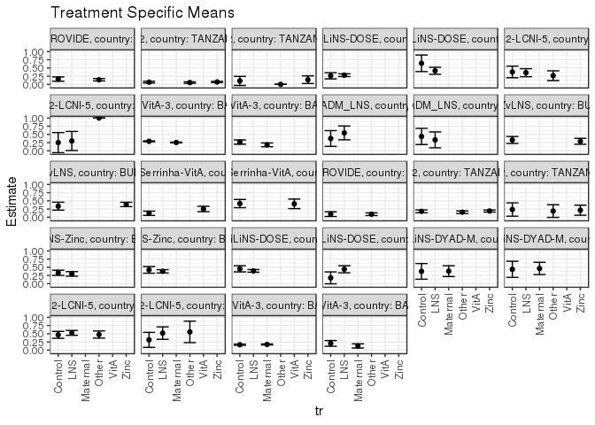

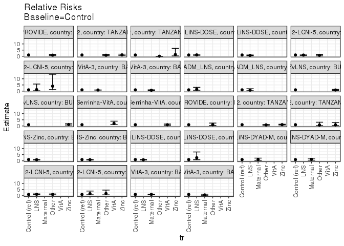

[figure not shown]

[figure not shown]

## Results Table

### Parameter: TSM

| agecat | studyid | country | intXnchldlt5 | intervention_level | baseline_level | estimate | ci_lower | ci_upper |
| --- | --- | --- | --- | --- | --- | --- | --- | --- |
| 0-6 months | ki1017093b-PROVIDE | BANGLADESH | 1_0-6 months | Control | NA | 0.1610169 | 0.0946300 | 0.2274039 |
| 0-6 months | ki1017093b-PROVIDE | BANGLADESH | 1_0-6 months | Other | NA | 0.1396011 | 0.1033057 | 0.1758966 |
| 0-6 months | ki1066203-TanzaniaChild2 | TANZANIA, UNITED REPUBLIC OF | 1_0-6 months | Control | NA | 0.0678851 | 0.0426844 | 0.0930859 |
| 0-6 months | ki1066203-TanzaniaChild2 | TANZANIA, UNITED REPUBLIC OF | 1_0-6 months | Other | NA | 0.0542636 | 0.0316861 | 0.0768410 |
| 0-6 months | ki1066203-TanzaniaChild2 | TANZANIA, UNITED REPUBLIC OF | 1_0-6 months | Zinc | NA | 0.0732357 | 0.0545969 | 0.0918744 |
| 0-6 months | ki1066203-TanzaniaChild2 | TANZANIA, UNITED REPUBLIC OF | 2+_0-6 months | Control | NA | 0.1052632 | -0.0337262 | 0.2442525 |
| 0-6 months | ki1066203-TanzaniaChild2 | TANZANIA, UNITED REPUBLIC OF | 2+_0-6 months | Other | NA | 0.0000000 | 0.0000000 | 0.0000000 |
| 0-6 months | ki1066203-TanzaniaChild2 | TANZANIA, UNITED REPUBLIC OF | 2+_0-6 months | Zinc | NA | 0.1428571 | 0.0260912 | 0.2596231 |
| 0-6 months | ki1148112-iLiNS-DOSE | MALAWI | 1_0-6 months | Control | NA | 0.2619048 | 0.1677931 | 0.3560164 |
| 0-6 months | ki1148112-iLiNS-DOSE | MALAWI | 1_0-6 months | LNS | NA | 0.2800000 | 0.2384765 | 0.3215235 |
| 0-6 months | ki1148112-iLiNS-DOSE | MALAWI | 2+_0-6 months | Control | NA | 0.6428571 | 0.3905462 | 0.8951681 |
| 0-6 months | ki1148112-iLiNS-DOSE | MALAWI | 2+_0-6 months | LNS | NA | 0.4146341 | 0.3074424 | 0.5218259 |
| 0-6 months | ki1148112-LCNI-5 | MALAWI | 1_0-6 months | Control | NA | 0.3793103 | 0.2019850 | 0.5566357 |
| 0-6 months | ki1148112-LCNI-5 | MALAWI | 1_0-6 months | LNS | NA | 0.3559322 | 0.2332564 | 0.4786080 |
| 0-6 months | ki1148112-LCNI-5 | MALAWI | 1_0-6 months | Other | NA | 0.2647059 | 0.1158013 | 0.4136105 |
| 0-6 months | ki1148112-LCNI-5 | MALAWI | 2+_0-6 months | Control | NA | 0.2500000 | -0.0568007 | 0.5568007 |
| 0-6 months | ki1148112-LCNI-5 | MALAWI | 2+_0-6 months | LNS | NA | 0.3000000 | 0.0095908 | 0.5904092 |
| 0-6 months | ki1148112-LCNI-5 | MALAWI | 2+_0-6 months | Other | NA | 1.0000000 | 1.0000000 | 1.0000000 |
| 0-6 months | kiGH5241-JiVitA-3 | BANGLADESH | 1_0-6 months | Control | NA | 0.2890638 | 0.2754375 | 0.3026901 |
| 0-6 months | kiGH5241-JiVitA-3 | BANGLADESH | 1_0-6 months | Maternal | NA | 0.2529084 | 0.2411028 | 0.2647140 |
| 0-6 months | kiGH5241-JiVitA-3 | BANGLADESH | 2+_0-6 months | Control | NA | 0.2657658 | 0.2008231 | 0.3307084 |
| 0-6 months | kiGH5241-JiVitA-3 | BANGLADESH | 2+_0-6 months | Maternal | NA | 0.1826087 | 0.1250401 | 0.2401773 |
| 6-24 months | iLiNS_DYADM_LNS | MALAWI | 1_6-24 months | Control | NA | 0.3750000 | 0.1345999 | 0.6154001 |
| 6-24 months | iLiNS_DYADM_LNS | MALAWI | 1_6-24 months | LNS | NA | 0.5454545 | 0.3345939 | 0.7563152 |
| 6-24 months | iLiNS_DYADM_LNS | MALAWI | 2+_6-24 months | Control | NA | 0.4375000 | 0.1904080 | 0.6845920 |
| 6-24 months | iLiNS_DYADM_LNS | MALAWI | 2+_6-24 months | LNS | NA | 0.3333333 | 0.0908307 | 0.5758359 |
| 6-24 months | iLiNS-Zinc_ZvLNS | BURKINA FASO | 1_6-24 months | Control | NA | 0.3297872 | 0.2237215 | 0.4358530 |
| 6-24 months | iLiNS-Zinc_ZvLNS | BURKINA FASO | 1_6-24 months | Zinc | NA | 0.2889246 | 0.1979569 | 0.3798923 |
| 6-24 months | iLiNS-Zinc_ZvLNS | BURKINA FASO | 2+_6-24 months | Control | NA | 0.3375000 | 0.2161961 | 0.4588039 |
| 6-24 months | iLiNS-Zinc_ZvLNS | BURKINA FASO | 2+_6-24 months | Zinc | NA | 0.3900862 | 0.3235808 | 0.4565916 |
| 6-24 months | ki1000107-Serrinha-VitA | BRAZIL | 1_6-24 months | Control | NA | 0.1212121 | 0.0567652 | 0.1856591 |
| 6-24 months | ki1000107-Serrinha-VitA | BRAZIL | 1_6-24 months | VitA | NA | 0.2523364 | 0.1698361 | 0.3348368 |
| 6-24 months | ki1000107-Serrinha-VitA | BRAZIL | 2+_6-24 months | Control | NA | 0.4166667 | 0.2913170 | 0.5420164 |
| 6-24 months | ki1000107-Serrinha-VitA | BRAZIL | 2+_6-24 months | VitA | NA | 0.4090909 | 0.2631120 | 0.5550698 |
| 6-24 months | ki1017093b-PROVIDE | BANGLADESH | 1_6-24 months | Control | NA | 0.0952381 | 0.0226113 | 0.1678649 |
| 6-24 months | ki1017093b-PROVIDE | BANGLADESH | 1_6-24 months | Other | NA | 0.0927835 | 0.0518777 | 0.1336893 |
| 6-24 months | ki1066203-TanzaniaChild2 | TANZANIA, UNITED REPUBLIC OF | 1_6-24 months | Control | NA | 0.1797386 | 0.1366996 | 0.2227775 |
| 6-24 months | ki1066203-TanzaniaChild2 | TANZANIA, UNITED REPUBLIC OF | 1_6-24 months | Other | NA | 0.1538462 | 0.1146041 | 0.1930882 |
| 6-24 months | ki1066203-TanzaniaChild2 | TANZANIA, UNITED REPUBLIC OF | 1_6-24 months | Zinc | NA | 0.1899160 | 0.1583868 | 0.2214451 |
| 6-24 months | ki1066203-TanzaniaChild2 | TANZANIA, UNITED REPUBLIC OF | 2+_6-24 months | Control | NA | 0.2352941 | 0.0319809 | 0.4386074 |
| 6-24 months | ki1066203-TanzaniaChild2 | TANZANIA, UNITED REPUBLIC OF | 2+_6-24 months | Other | NA | 0.1875000 | -0.0053367 | 0.3803367 |
| 6-24 months | ki1066203-TanzaniaChild2 | TANZANIA, UNITED REPUBLIC OF | 2+_6-24 months | Zinc | NA | 0.2142857 | 0.0610404 | 0.3675311 |
| 6-24 months | ki1112895-iLiNS-Zinc | BURKINA FASO | 1_6-24 months | Control | NA | 0.3320611 | 0.2526171 | 0.4115050 |
| 6-24 months | ki1112895-iLiNS-Zinc | BURKINA FASO | 1_6-24 months | LNS | NA | 0.2983970 | 0.2291186 | 0.3676755 |
| 6-24 months | ki1112895-iLiNS-Zinc | BURKINA FASO | 2+_6-24 months | Control | NA | 0.4200913 | 0.3188552 | 0.5213274 |
| 6-24 months | ki1112895-iLiNS-Zinc | BURKINA FASO | 2+_6-24 months | LNS | NA | 0.3766026 | 0.3258934 | 0.4273117 |
| 6-24 months | ki1148112-iLiNS-DOSE | MALAWI | 1_6-24 months | Control | NA | 0.4537037 | 0.3597388 | 0.5476686 |
| 6-24 months | ki1148112-iLiNS-DOSE | MALAWI | 1_6-24 months | LNS | NA | 0.3894928 | 0.3487826 | 0.4302029 |
| 6-24 months | ki1148112-iLiNS-DOSE | MALAWI | 2+_6-24 months | Control | NA | 0.1764706 | -0.0056688 | 0.3586100 |
| 6-24 months | ki1148112-iLiNS-DOSE | MALAWI | 2+_6-24 months | LNS | NA | 0.4390244 | 0.3310646 | 0.5469842 |
| 6-24 months | ki1148112-iLiNS-DYAD-M | MALAWI | 1_6-24 months | Control | NA | 0.3750000 | 0.1353758 | 0.6146242 |
| 6-24 months | ki1148112-iLiNS-DYAD-M | MALAWI | 1_6-24 months | Maternal | NA | 0.3823529 | 0.2173476 | 0.5473583 |
| 6-24 months | ki1148112-iLiNS-DYAD-M | MALAWI | 2+_6-24 months | Control | NA | 0.4375000 | 0.1916159 | 0.6833841 |
| 6-24 months | ki1148112-iLiNS-DYAD-M | MALAWI | 2+_6-24 months | Maternal | NA | 0.4642857 | 0.2774239 | 0.6511475 |
| 6-24 months | ki1148112-LCNI-5 | MALAWI | 1_6-24 months | Control | NA | 0.4651163 | 0.3595456 | 0.5706870 |
| 6-24 months | ki1148112-LCNI-5 | MALAWI | 1_6-24 months | LNS | NA | 0.5254237 | 0.4517516 | 0.5990959 |
| 6-24 months | ki1148112-LCNI-5 | MALAWI | 1_6-24 months | Other | NA | 0.4750000 | 0.3654119 | 0.5845881 |
| 6-24 months | ki1148112-LCNI-5 | MALAWI | 2+_6-24 months | Control | NA | 0.3125000 | 0.0831673 | 0.5418327 |
| 6-24 months | ki1148112-LCNI-5 | MALAWI | 2+_6-24 months | LNS | NA | 0.5185185 | 0.3282115 | 0.7088255 |
| 6-24 months | ki1148112-LCNI-5 | MALAWI | 2+_6-24 months | Other | NA | 0.5555556 | 0.2277503 | 0.8833608 |
| 6-24 months | kiGH5241-JiVitA-3 | BANGLADESH | 1_6-24 months | Control | NA | 0.1645179 | 0.1455799 | 0.1834559 |
| 6-24 months | kiGH5241-JiVitA-3 | BANGLADESH | 1_6-24 months | Maternal | NA | 0.1722625 | 0.1572741 | 0.1872510 |
| 6-24 months | kiGH5241-JiVitA-3 | BANGLADESH | 2+_6-24 months | Control | NA | 0.2043011 | 0.1164767 | 0.2921254 |
| 6-24 months | kiGH5241-JiVitA-3 | BANGLADESH | 2+_6-24 months | Maternal | NA | 0.1269841 | 0.0632322 | 0.1907361 |

### Parameter: E(Y)

| agecat | studyid | country | intXnchldlt5 | intervention_level | baseline_level | estimate | ci_lower | ci_upper |
| --- | --- | --- | --- | --- | --- | --- | --- | --- |
| 0-6 months | ki1017093b-PROVIDE | BANGLADESH | 1_0-6 months | NA | NA | 0.1449893 | 0.1130902 | 0.1768885 |
| 0-6 months | ki1066203-TanzaniaChild2 | TANZANIA, UNITED REPUBLIC OF | 1_0-6 months | NA | NA | 0.0670611 | 0.0544867 | 0.0796356 |
| 0-6 months | ki1066203-TanzaniaChild2 | TANZANIA, UNITED REPUBLIC OF | 2+_0-6 months | NA | NA | 0.1000000 | 0.0292144 | 0.1707856 |
| 0-6 months | ki1148112-iLiNS-DOSE | MALAWI | 1_0-6 months | NA | NA | 0.2771536 | 0.2391549 | 0.3151522 |
| 0-6 months | ki1148112-iLiNS-DOSE | MALAWI | 2+_0-6 months | NA | NA | 0.4479167 | 0.3479196 | 0.5479137 |
| 0-6 months | ki1148112-LCNI-5 | MALAWI | 1_0-6 months | NA | NA | 0.3360656 | 0.2519009 | 0.4202303 |
| 0-6 months | ki1148112-LCNI-5 | MALAWI | 2+_0-6 months | NA | NA | 0.4347826 | 0.2276347 | 0.6419305 |
| 0-6 months | kiGH5241-JiVitA-3 | BANGLADESH | 1_0-6 months | NA | NA | 0.2707289 | 0.2616040 | 0.2798539 |
| 0-6 months | kiGH5241-JiVitA-3 | BANGLADESH | 2+_0-6 months | NA | NA | 0.2234513 | 0.1799227 | 0.2669799 |
| 6-24 months | iLiNS_DYADM_LNS | MALAWI | 1_6-24 months | NA | NA | 0.4736842 | 0.3127995 | 0.6345690 |
| 6-24 months | iLiNS_DYADM_LNS | MALAWI | 2+_6-24 months | NA | NA | 0.3870968 | 0.2127985 | 0.5613951 |
| 6-24 months | iLiNS-Zinc_ZvLNS | BURKINA FASO | 1_6-24 months | NA | NA | 0.2983970 | 0.2269583 | 0.3698358 |
| 6-24 months | iLiNS-Zinc_ZvLNS | BURKINA FASO | 2+_6-24 months | NA | NA | 0.3766026 | 0.3248322 | 0.4283729 |
| 6-24 months | ki1000107-Serrinha-VitA | BRAZIL | 1_6-24 months | NA | NA | 0.1893204 | 0.1356920 | 0.2429487 |
| 6-24 months | ki1000107-Serrinha-VitA | BRAZIL | 2+_6-24 months | NA | NA | 0.4134615 | 0.3183583 | 0.5085648 |
| 6-24 months | ki1017093b-PROVIDE | BANGLADESH | 1_6-24 months | NA | NA | 0.0933852 | 0.0577419 | 0.1290286 |
| 6-24 months | ki1066203-TanzaniaChild2 | TANZANIA, UNITED REPUBLIC OF | 1_6-24 months | NA | NA | 0.1778140 | 0.1564025 | 0.1992256 |
| 6-24 months | ki1066203-TanzaniaChild2 | TANZANIA, UNITED REPUBLIC OF | 2+_6-24 months | NA | NA | 0.2131148 | 0.1094968 | 0.3167327 |
| 6-24 months | ki1112895-iLiNS-Zinc | BURKINA FASO | 1_6-24 months | NA | NA | 0.3066170 | 0.2508978 | 0.3623361 |
| 6-24 months | ki1112895-iLiNS-Zinc | BURKINA FASO | 2+_6-24 months | NA | NA | 0.3879004 | 0.3426651 | 0.4331356 |
| 6-24 months | ki1148112-iLiNS-DOSE | MALAWI | 1_6-24 months | NA | NA | 0.4000000 | 0.3625966 | 0.4374034 |
| 6-24 months | ki1148112-iLiNS-DOSE | MALAWI | 2+_6-24 months | NA | NA | 0.3939394 | 0.2971990 | 0.4906798 |
| 6-24 months | ki1148112-iLiNS-DYAD-M | MALAWI | 1_6-24 months | NA | NA | 0.3800000 | 0.2440943 | 0.5159057 |
| 6-24 months | ki1148112-iLiNS-DYAD-M | MALAWI | 2+_6-24 months | NA | NA | 0.4545455 | 0.3057184 | 0.6033725 |
| 6-24 months | ki1148112-LCNI-5 | MALAWI | 1_6-24 months | NA | NA | 0.4985423 | 0.4455511 | 0.5515334 |
| 6-24 months | ki1148112-LCNI-5 | MALAWI | 2+_6-24 months | NA | NA | 0.4615385 | 0.3247201 | 0.5983568 |
| 6-24 months | kiGH5241-JiVitA-3 | BANGLADESH | 1_6-24 months | NA | NA | 0.1685324 | 0.1565567 | 0.1805082 |
| 6-24 months | kiGH5241-JiVitA-3 | BANGLADESH | 2+_6-24 months | NA | NA | 0.1653333 | 0.1108090 | 0.2198577 |

### Parameter: RR

| agecat | studyid | country | intXnchldlt5 | intervention_level | baseline_level | estimate | ci_lower | ci_upper |
| --- | --- | --- | --- | --- | --- | --- | --- | --- |
| 0-6 months | ki1017093b-PROVIDE | BANGLADESH | 1_0-6 months | Control | Control | 1.0000000 | 1.0000000 | 1.0000000 |
| 0-6 months | ki1017093b-PROVIDE | BANGLADESH | 1_0-6 months | Other | Control | 0.8669966 | 0.5325125 | 1.4115782 |
| 0-6 months | ki1066203-TanzaniaChild2 | TANZANIA, UNITED REPUBLIC OF | 1_0-6 months | Control | Control | 1.0000000 | 1.0000000 | 1.0000000 |
| 0-6 months | ki1066203-TanzaniaChild2 | TANZANIA, UNITED REPUBLIC OF | 1_0-6 months | Other | Control | 0.7993441 | 0.4576875 | 1.3960421 |
| 0-6 months | ki1066203-TanzaniaChild2 | TANZANIA, UNITED REPUBLIC OF | 1_0-6 months | Zinc | Control | 1.0788180 | 0.6878226 | 1.6920762 |
| 0-6 months | ki1066203-TanzaniaChild2 | TANZANIA, UNITED REPUBLIC OF | 2+_0-6 months | Control | Control | 1.0000000 | 1.0000000 | 1.0000000 |
| 0-6 months | ki1066203-TanzaniaChild2 | TANZANIA, UNITED REPUBLIC OF | 2+_0-6 months | Other | Control | 0.0000000 | 0.0000000 | 0.0000001 |
| 0-6 months | ki1066203-TanzaniaChild2 | TANZANIA, UNITED REPUBLIC OF | 2+_0-6 months | Zinc | Control | 1.3571429 | 0.2872134 | 6.4127808 |
| 0-6 months | ki1148112-iLiNS-DOSE | MALAWI | 1_0-6 months | Control | Control | 1.0000000 | 1.0000000 | 1.0000000 |
| 0-6 months | ki1148112-iLiNS-DOSE | MALAWI | 1_0-6 months | LNS | Control | 1.0690909 | 0.7247521 | 1.5770293 |
| 0-6 months | ki1148112-iLiNS-DOSE | MALAWI | 2+_0-6 months | Control | Control | 1.0000000 | 1.0000000 | 1.0000000 |
| 0-6 months | ki1148112-iLiNS-DOSE | MALAWI | 2+_0-6 months | LNS | Control | 0.6449864 | 0.4031280 | 1.0319490 |
| 0-6 months | ki1148112-LCNI-5 | MALAWI | 1_0-6 months | Control | Control | 1.0000000 | 1.0000000 | 1.0000000 |
| 0-6 months | ki1148112-LCNI-5 | MALAWI | 1_0-6 months | LNS | Control | 0.9383667 | 0.5249640 | 1.6773191 |
| 0-6 months | ki1148112-LCNI-5 | MALAWI | 1_0-6 months | Other | Control | 0.6978610 | 0.3358250 | 1.4501895 |
| 0-6 months | ki1148112-LCNI-5 | MALAWI | 2+_0-6 months | Control | Control | 1.0000000 | 1.0000000 | 1.0000000 |
| 0-6 months | ki1148112-LCNI-5 | MALAWI | 2+_0-6 months | LNS | Control | 1.2000000 | 0.2513966 | 5.7280006 |
| 0-6 months | ki1148112-LCNI-5 | MALAWI | 2+_0-6 months | Other | Control | 4.0000000 | 1.1724454 | 13.6466907 |
| 0-6 months | kiGH5241-JiVitA-3 | BANGLADESH | 1_0-6 months | Control | Control | 1.0000000 | 1.0000000 | 1.0000000 |
| 0-6 months | kiGH5241-JiVitA-3 | BANGLADESH | 1_0-6 months | Maternal | Control | 0.8749224 | 0.8187427 | 0.9349569 |
| 0-6 months | kiGH5241-JiVitA-3 | BANGLADESH | 2+_0-6 months | Control | Control | 1.0000000 | 1.0000000 | 1.0000000 |
| 0-6 months | kiGH5241-JiVitA-3 | BANGLADESH | 2+_0-6 months | Maternal | Control | 0.6871039 | 0.4610642 | 1.0239611 |
| 6-24 months | iLiNS_DYADM_LNS | MALAWI | 1_6-24 months | Control | Control | 1.0000000 | 1.0000000 | 1.0000000 |
| 6-24 months | iLiNS_DYADM_LNS | MALAWI | 1_6-24 months | LNS | Control | 1.4545455 | 0.6880378 | 3.0749800 |
| 6-24 months | iLiNS_DYADM_LNS | MALAWI | 2+_6-24 months | Control | Control | 1.0000000 | 1.0000000 | 1.0000000 |
| 6-24 months | iLiNS_DYADM_LNS | MALAWI | 2+_6-24 months | LNS | Control | 0.7619048 | 0.3033293 | 1.9137582 |
| 6-24 months | iLiNS-Zinc_ZvLNS | BURKINA FASO | 1_6-24 months | Control | Control | 1.0000000 | 1.0000000 | 1.0000000 |
| 6-24 months | iLiNS-Zinc_ZvLNS | BURKINA FASO | 1_6-24 months | Zinc | Control | 0.8760938 | 0.5502653 | 1.3948553 |
| 6-24 months | iLiNS-Zinc_ZvLNS | BURKINA FASO | 2+_6-24 months | Control | Control | 1.0000000 | 1.0000000 | 1.0000000 |
| 6-24 months | iLiNS-Zinc_ZvLNS | BURKINA FASO | 2+_6-24 months | Zinc | Control | 1.1558110 | 0.7504498 | 1.7801312 |
| 6-24 months | ki1000107-Serrinha-VitA | BRAZIL | 1_6-24 months | Control | Control | 1.0000000 | 1.0000000 | 1.0000000 |
| 6-24 months | ki1000107-Serrinha-VitA | BRAZIL | 1_6-24 months | VitA | Control | 2.0817757 | 1.1152224 | 3.8860321 |
| 6-24 months | ki1000107-Serrinha-VitA | BRAZIL | 2+_6-24 months | Control | Control | 1.0000000 | 1.0000000 | 1.0000000 |
| 6-24 months | ki1000107-Serrinha-VitA | BRAZIL | 2+_6-24 months | VitA | Control | 0.9818182 | 0.6156483 | 1.5657753 |
| 6-24 months | ki1017093b-PROVIDE | BANGLADESH | 1_6-24 months | Control | Control | 1.0000000 | 1.0000000 | 1.0000000 |
| 6-24 months | ki1017093b-PROVIDE | BANGLADESH | 1_6-24 months | Other | Control | 0.9742268 | 0.4037486 | 2.3507644 |
| 6-24 months | ki1066203-TanzaniaChild2 | TANZANIA, UNITED REPUBLIC OF | 1_6-24 months | Control | Control | 1.0000000 | 1.0000000 | 1.0000000 |
| 6-24 months | ki1066203-TanzaniaChild2 | TANZANIA, UNITED REPUBLIC OF | 1_6-24 months | Other | Control | 0.8559441 | 0.6032597 | 1.2144690 |
| 6-24 months | ki1066203-TanzaniaChild2 | TANZANIA, UNITED REPUBLIC OF | 1_6-24 months | Zinc | Control | 1.0566234 | 0.7895467 | 1.4140429 |
| 6-24 months | ki1066203-TanzaniaChild2 | TANZANIA, UNITED REPUBLIC OF | 2+_6-24 months | Control | Control | 1.0000000 | 1.0000000 | 1.0000000 |
| 6-24 months | ki1066203-TanzaniaChild2 | TANZANIA, UNITED REPUBLIC OF | 2+_6-24 months | Other | Control | 0.7968750 | 0.2079773 | 3.0532650 |
| 6-24 months | ki1066203-TanzaniaChild2 | TANZANIA, UNITED REPUBLIC OF | 2+_6-24 months | Zinc | Control | 0.9107143 | 0.2966617 | 2.7957785 |
| 6-24 months | ki1112895-iLiNS-Zinc | BURKINA FASO | 1_6-24 months | Control | Control | 1.0000000 | 1.0000000 | 1.0000000 |
| 6-24 months | ki1112895-iLiNS-Zinc | BURKINA FASO | 1_6-24 months | LNS | Control | 0.8986210 | 0.6442465 | 1.2534327 |
| 6-24 months | ki1112895-iLiNS-Zinc | BURKINA FASO | 2+_6-24 months | Control | Control | 1.0000000 | 1.0000000 | 1.0000000 |
| 6-24 months | ki1112895-iLiNS-Zinc | BURKINA FASO | 2+_6-24 months | LNS | Control | 0.8964778 | 0.6820383 | 1.1783393 |
| 6-24 months | ki1148112-iLiNS-DOSE | MALAWI | 1_6-24 months | Control | Control | 1.0000000 | 1.0000000 | 1.0000000 |
| 6-24 months | ki1148112-iLiNS-DOSE | MALAWI | 1_6-24 months | LNS | Control | 0.8584738 | 0.6807328 | 1.0826235 |
| 6-24 months | ki1148112-iLiNS-DOSE | MALAWI | 2+_6-24 months | Control | Control | 1.0000000 | 1.0000000 | 1.0000000 |
| 6-24 months | ki1148112-iLiNS-DOSE | MALAWI | 2+_6-24 months | LNS | Control | 2.4878048 | 0.8610414 | 7.1880080 |
| 6-24 months | ki1148112-iLiNS-DYAD-M | MALAWI | 1_6-24 months | Control | Control | 1.0000000 | 1.0000000 | 1.0000000 |
| 6-24 months | ki1148112-iLiNS-DYAD-M | MALAWI | 1_6-24 months | Maternal | Control | 1.0196078 | 0.4715848 | 2.2044820 |
| 6-24 months | ki1148112-iLiNS-DYAD-M | MALAWI | 2+_6-24 months | Control | Control | 1.0000000 | 1.0000000 | 1.0000000 |
| 6-24 months | ki1148112-iLiNS-DYAD-M | MALAWI | 2+_6-24 months | Maternal | Control | 1.0612245 | 0.5316106 | 2.1184632 |
| 6-24 months | ki1148112-LCNI-5 | MALAWI | 1_6-24 months | Control | Control | 1.0000000 | 1.0000000 | 1.0000000 |
| 6-24 months | ki1148112-LCNI-5 | MALAWI | 1_6-24 months | LNS | Control | 1.1296610 | 0.8651297 | 1.4750782 |
| 6-24 months | ki1148112-LCNI-5 | MALAWI | 1_6-24 months | Other | Control | 1.0212500 | 0.7388811 | 1.4115283 |
| 6-24 months | ki1148112-LCNI-5 | MALAWI | 2+_6-24 months | Control | Control | 1.0000000 | 1.0000000 | 1.0000000 |
| 6-24 months | ki1148112-LCNI-5 | MALAWI | 2+_6-24 months | LNS | Control | 1.6592593 | 0.7304066 | 3.7693270 |
| 6-24 months | ki1148112-LCNI-5 | MALAWI | 2+_6-24 months | Other | Control | 1.7777778 | 0.6933005 | 4.5586204 |
| 6-24 months | kiGH5241-JiVitA-3 | BANGLADESH | 1_6-24 months | Control | Control | 1.0000000 | 1.0000000 | 1.0000000 |
| 6-24 months | kiGH5241-JiVitA-3 | BANGLADESH | 1_6-24 months | Maternal | Control | 1.0470748 | 0.9064386 | 1.2095310 |
| 6-24 months | kiGH5241-JiVitA-3 | BANGLADESH | 2+_6-24 months | Control | Control | 1.0000000 | 1.0000000 | 1.0000000 |
| 6-24 months | kiGH5241-JiVitA-3 | BANGLADESH | 2+_6-24 months | Maternal | Control | 0.6215539 | 0.3209313 | 1.2037754 |

### Parameter: PAR

| agecat | studyid | country | intXnchldlt5 | intervention_level | baseline_level | estimate | ci_lower | ci_upper |
| --- | --- | --- | --- | --- | --- | --- | --- | --- |
| 0-6 months | ki1017093b-PROVIDE | BANGLADESH | 1_0-6 months | Control | NA | -0.0160276 | -0.0726587 | 0.0406034 |
| 0-6 months | ki1066203-TanzaniaChild2 | TANZANIA, UNITED REPUBLIC OF | 1_0-6 months | Control | NA | -0.0008240 | -0.0225808 | 0.0209328 |
| 0-6 months | ki1066203-TanzaniaChild2 | TANZANIA, UNITED REPUBLIC OF | 2+_0-6 months | Control | NA | -0.0052632 | -0.1229139 | 0.1123876 |
| 0-6 months | ki1148112-iLiNS-DOSE | MALAWI | 1_0-6 months | Control | NA | 0.0152488 | -0.0714370 | 0.1019346 |
| 0-6 months | ki1148112-iLiNS-DOSE | MALAWI | 2+_0-6 months | Control | NA | -0.1949405 | -0.4296584 | 0.0397774 |
| 0-6 months | ki1148112-LCNI-5 | MALAWI | 1_0-6 months | Control | NA | -0.0432448 | -0.1967995 | 0.1103100 |
| 0-6 months | ki1148112-LCNI-5 | MALAWI | 2+_0-6 months | Control | NA | 0.1847826 | -0.0827197 | 0.4522850 |
| 0-6 months | kiGH5241-JiVitA-3 | BANGLADESH | 1_0-6 months | Control | NA | -0.0183348 | -0.0276520 | -0.0090177 |
| 0-6 months | kiGH5241-JiVitA-3 | BANGLADESH | 2+_0-6 months | Control | NA | -0.0423144 | -0.0866035 | 0.0019747 |
| 6-24 months | iLiNS_DYADM_LNS | MALAWI | 1_6-24 months | Control | NA | 0.0986842 | -0.0884227 | 0.2857911 |
| 6-24 months | iLiNS_DYADM_LNS | MALAWI | 2+_6-24 months | Control | NA | -0.0504032 | -0.2189571 | 0.1181506 |
| 6-24 months | iLiNS-Zinc_ZvLNS | BURKINA FASO | 1_6-24 months | Control | NA | -0.0313902 | -0.1419478 | 0.0791674 |
| 6-24 months | iLiNS-Zinc_ZvLNS | BURKINA FASO | 2+_6-24 months | Control | NA | 0.0391026 | -0.0727944 | 0.1509995 |
| 6-24 months | ki1000107-Serrinha-VitA | BRAZIL | 1_6-24 months | Control | NA | 0.0681083 | 0.0129966 | 0.1232200 |
| 6-24 months | ki1000107-Serrinha-VitA | BRAZIL | 2+_6-24 months | Control | NA | -0.0032051 | -0.0846134 | 0.0782032 |
| 6-24 months | ki1017093b-PROVIDE | BANGLADESH | 1_6-24 months | Control | NA | -0.0018529 | -0.0647741 | 0.0610684 |
| 6-24 months | ki1066203-TanzaniaChild2 | TANZANIA, UNITED REPUBLIC OF | 1_6-24 months | Control | NA | -0.0019245 | -0.0391554 | 0.0353064 |
| 6-24 months | ki1066203-TanzaniaChild2 | TANZANIA, UNITED REPUBLIC OF | 2+_6-24 months | Control | NA | -0.0221794 | -0.1925703 | 0.1482115 |
| 6-24 months | ki1112895-iLiNS-Zinc | BURKINA FASO | 1_6-24 months | Control | NA | -0.0254441 | -0.1051086 | 0.0542204 |
| 6-24 months | ki1112895-iLiNS-Zinc | BURKINA FASO | 2+_6-24 months | Control | NA | -0.0321910 | -0.1170863 | 0.0527043 |
| 6-24 months | ki1148112-iLiNS-DOSE | MALAWI | 1_6-24 months | Control | NA | -0.0537037 | -0.1393705 | 0.0319631 |
| 6-24 months | ki1148112-iLiNS-DOSE | MALAWI | 2+_6-24 months | Control | NA | 0.2174688 | 0.0410032 | 0.3939344 |
| 6-24 months | ki1148112-iLiNS-DYAD-M | MALAWI | 1_6-24 months | Control | NA | 0.0050000 | -0.1928420 | 0.2028420 |
| 6-24 months | ki1148112-iLiNS-DYAD-M | MALAWI | 2+_6-24 months | Control | NA | 0.0170455 | -0.1795208 | 0.2136117 |
| 6-24 months | ki1148112-LCNI-5 | MALAWI | 1_6-24 months | Control | NA | 0.0334260 | -0.0580311 | 0.1248831 |
| 6-24 months | ki1148112-LCNI-5 | MALAWI | 2+_6-24 months | Control | NA | 0.1490385 | -0.0483128 | 0.3463897 |
| 6-24 months | kiGH5241-JiVitA-3 | BANGLADESH | 1_6-24 months | Control | NA | 0.0040146 | -0.0085114 | 0.0165406 |
| 6-24 months | kiGH5241-JiVitA-3 | BANGLADESH | 2+_6-24 months | Control | NA | -0.0389677 | -0.0941334 | 0.0161979 |

### Parameter: PAF

| agecat | studyid | country | intXnchldlt5 | intervention_level | baseline_level | estimate | ci_lower | ci_upper |
| --- | --- | --- | --- | --- | --- | --- | --- | --- |
| 0-6 months | ki1017093b-PROVIDE | BANGLADESH | 1_0-6 months | Control | NA | -0.1105434 | -0.5779598 | 0.2184170 |
| 0-6 months | ki1066203-TanzaniaChild2 | TANZANIA, UNITED REPUBLIC OF | 1_0-6 months | Control | NA | -0.0122869 | -0.3947284 | 0.2652872 |
| 0-6 months | ki1066203-TanzaniaChild2 | TANZANIA, UNITED REPUBLIC OF | 2+_0-6 months | Control | NA | -0.0526316 | -2.2173123 | 0.6556028 |
| 0-6 months | ki1148112-iLiNS-DOSE | MALAWI | 1_0-6 months | Control | NA | 0.0550193 | -0.3156946 | 0.3212798 |
| 0-6 months | ki1148112-iLiNS-DOSE | MALAWI | 2+_0-6 months | Control | NA | -0.4352159 | -1.0848125 | 0.0119760 |
| 0-6 months | ki1148112-LCNI-5 | MALAWI | 1_0-6 months | Control | NA | -0.1286796 | -0.6921809 | 0.2471741 |
| 0-6 months | ki1148112-LCNI-5 | MALAWI | 2+_0-6 months | Control | NA | 0.4250000 | -0.6651526 | 0.8014446 |
| 0-6 months | kiGH5241-JiVitA-3 | BANGLADESH | 1_0-6 months | Control | NA | -0.0677239 | -0.1025613 | -0.0339873 |
| 0-6 months | kiGH5241-JiVitA-3 | BANGLADESH | 2+_0-6 months | Control | NA | -0.1893676 | -0.4050163 | -0.0068177 |
| 6-24 months | iLiNS_DYADM_LNS | MALAWI | 1_6-24 months | Control | NA | 0.2083333 | -0.3082989 | 0.5209534 |
| 6-24 months | iLiNS_DYADM_LNS | MALAWI | 2+_6-24 months | Control | NA | -0.1302083 | -0.6638905 | 0.2322987 |
| 6-24 months | iLiNS-Zinc_ZvLNS | BURKINA FASO | 1_6-24 months | Control | NA | -0.1051961 | -0.5599759 | 0.2170018 |
| 6-24 months | iLiNS-Zinc_ZvLNS | BURKINA FASO | 2+_6-24 months | Control | NA | 0.1038298 | -0.2481161 | 0.3565334 |
| 6-24 months | ki1000107-Serrinha-VitA | BRAZIL | 1_6-24 months | Control | NA | 0.3597514 | 0.0111318 | 0.5854672 |
| 6-24 months | ki1000107-Serrinha-VitA | BRAZIL | 2+_6-24 months | Control | NA | -0.0077519 | -0.2252015 | 0.1711045 |
| 6-24 months | ki1017093b-PROVIDE | BANGLADESH | 1_6-24 months | Control | NA | -0.0198413 | -0.9744448 | 0.4732310 |
| 6-24 months | ki1066203-TanzaniaChild2 | TANZANIA, UNITED REPUBLIC OF | 1_6-24 months | Control | NA | -0.0108233 | -0.2434653 | 0.1782933 |
| 6-24 months | ki1066203-TanzaniaChild2 | TANZANIA, UNITED REPUBLIC OF | 2+_6-24 months | Control | NA | -0.1040724 | -1.2763737 | 0.4645098 |
| 6-24 months | ki1112895-iLiNS-Zinc | BURKINA FASO | 1_6-24 months | Control | NA | -0.0829834 | -0.3838917 | 0.1524966 |
| 6-24 months | ki1112895-iLiNS-Zinc | BURKINA FASO | 2+_6-24 months | Control | NA | -0.0829877 | -0.3242531 | 0.1143215 |
| 6-24 months | ki1148112-iLiNS-DOSE | MALAWI | 1_6-24 months | Control | NA | -0.1342593 | -0.3702079 | 0.0610593 |
| 6-24 months | ki1148112-iLiNS-DOSE | MALAWI | 2+_6-24 months | Control | NA | 0.5520362 | -0.1943685 | 0.8319852 |
| 6-24 months | ki1148112-iLiNS-DYAD-M | MALAWI | 1_6-24 months | Control | NA | 0.0131579 | -0.6725311 | 0.4177344 |
| 6-24 months | ki1148112-iLiNS-DYAD-M | MALAWI | 2+_6-24 months | Control | NA | 0.0375000 | -0.5086007 | 0.3859169 |
| 6-24 months | ki1148112-LCNI-5 | MALAWI | 1_6-24 months | Control | NA | 0.0670475 | -0.1358243 | 0.2336839 |
| 6-24 months | ki1148112-LCNI-5 | MALAWI | 2+_6-24 months | Control | NA | 0.3229167 | -0.2764738 | 0.6408529 |
| 6-24 months | kiGH5241-JiVitA-3 | BANGLADESH | 1_6-24 months | Control | NA | 0.0238207 | -0.0537810 | 0.0957077 |
| 6-24 months | kiGH5241-JiVitA-3 | BANGLADESH | 2+_6-24 months | Control | NA | -0.2356920 | -0.6016369 | 0.0466411 |